# HomeWork 3

William Mechler

3/7/2021

Part 1, reading in the data for this problem but only selecting needed columns.

```r
riceData <- read.table("rice.txt", header = TRUE) %>%
  select(moistureContent, amyloseContent, proteinContent, waterAbsorption, swellingRatio, pH, solidsContent, chewiness)
```

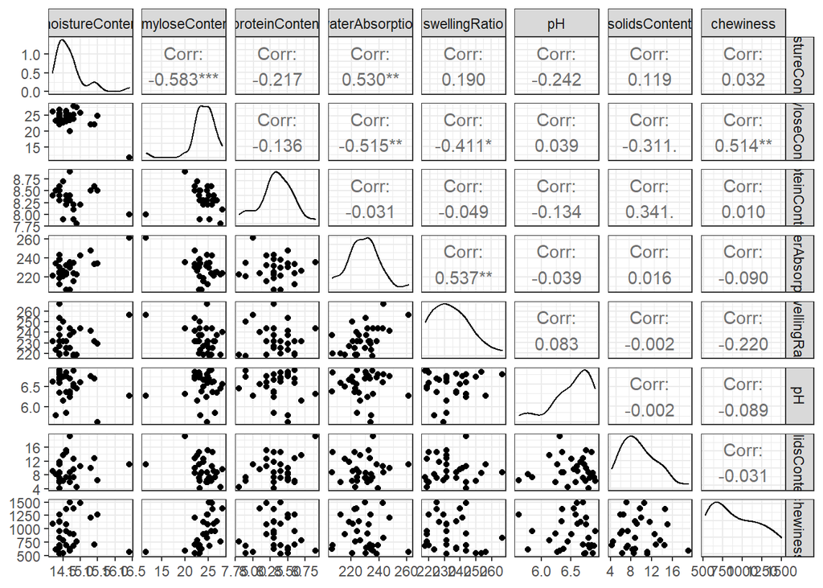

Part 2, from the above scatterplot matrix there appears to be some trends we can see. One of these trends is that most of our data points seems to have a low moisture content and a high amylose content. Besides that any other patterens I can see seem to be too light to call out at this point.

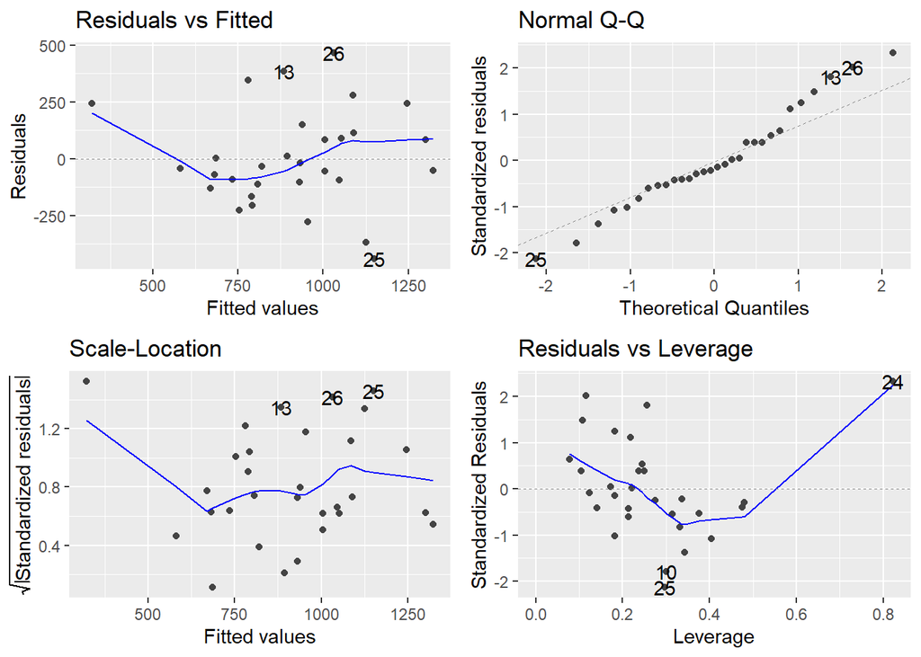

```r
riceFit1 <- lm(chewiness ~ moistureContent + amyloseContent + proteinContent + waterAbsorption + swellingRatio + pH + solidsContent, data=riceData)

autoplot(riceFit1)
```

Part 3, above you can see the code that fits a multiple regression modeling the chewiness as a function of the following variables moisture content, amylose content, protein content, water absorption, swelling ratio, pH, and solids content.

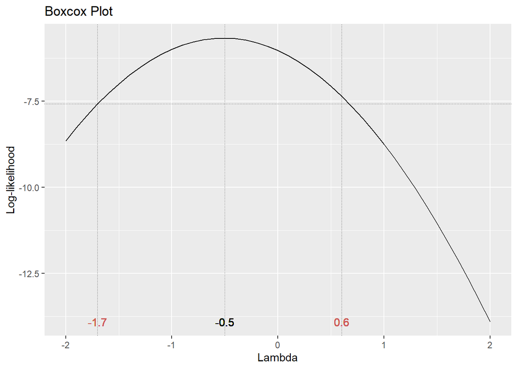

```r
gg_boxcox(riceFit1)
```

Part 5, The above box cox shows a optimal λ of -0.5, this would be a lambda of -0.5 would be applied as a negative square root.

[figure not shown]

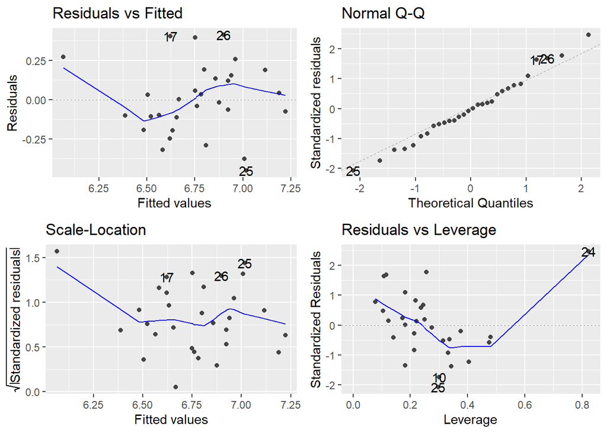

```r
riceFit_Part6 <- lm(log(chewiness) ~ moistureContent + amyloseContent + proteinContent + waterAbsorption + swellingRatio + pH + solidsContent, data=riceData)

autoplot(riceFit_Part6)
```

Part 6, above you can see the code that fits a multiple regression modeling the chewiness as a function of the following variables moisture content, amylose content, protein content, water absorption, swelling ratio, pH, and solids content. However we applied a log transformation as λ = 0 is within our confidence band.

```r
summary(riceFit_Part6)
```

```
##
## Call:
## lm(formula = log(chewiness) ~ moistureContent + amyloseContent +
##     proteinContent + waterAbsorption + swellingRatio + pH + solidsContent,
##     data = riceData)
##
## Residuals:
##      Min       1Q   Median       3Q      Max
## -0.45282 -0.11061 -0.00934  0.14833  0.41333
##
## Coefficients:
##                   Estimate Std. Error t value Pr(>|t|)
## (Intercept)     -6.7588157  4.5955284  -1.471   0.1555
## moistureContent  0.4582036  0.1660454   2.760   0.0114 *
## amyloseContent   0.1167137  0.0245046   4.763 9.37e-05 ***
## proteinContent   0.3590317  0.2387992   1.503   0.1469
## waterAbsorption  0.0022169  0.0058013   0.382   0.7060
## swellingRatio    0.0003959  0.0049336   0.080   0.9368
## pH               0.0444283  0.1527744   0.291   0.7739
## solidsContent    0.0111900  0.0156691   0.714   0.4826
## ---
## Signif. codes:  0 '***' 0.001 '**' 0.01 '*' 0.05 '.' 0.1 ' ' 1
##
## Residual standard error: 0.2606 on 22 degrees of freedom
## Multiple R-squared:  0.5449, Adjusted R-squared:  0.4001
## F-statistic: 3.763 on 7 and 22 DF,  p-value: 0.007886
```

Part 10,

```r
fictional_rice <- data.frame(moistureContent = 14.9,
                               amyloseContent = 22.6,
                               proteinContent = 8.1,
                               waterAbsorption = 211,
                               swellingRatio = 225,
                               pH = 6.6,
                               solidsContent   = 5.2)

predict(riceFit_Part6, newdata=fictional_rice, interval="prediction", level=0.95)
```

```
##        fit      lwr      upr
## 1 6.522571 5.895241 7.149901
```